# Danish Kings

Lauge Johannes Hansen

2026-13-03

```r
knitr::opts_chunk$set(echo = TRUE)
library(tidyverse)
```

The task here is to load your Danish Monarchs csv into R using the `tidyverse` toolkit, calculate and explore the kings’ duration of reign with pipes `%>%` in `dplyr` and plot it over time.

## Load the kings

1. Look at the dataset that are you loading and check what its columns are separated by? (hint: open it in plain text editor to see)

List what is the

separator: ‘kongerakken’ is separated by “;” ‘kings’ by “,”

2. Create a `kings` object in R with the different functions below and inspect the different outputs.
- `read.csv()`
- `read_csv()`
- `read.csv2()`
- `read_csv2()`

```r
# FILL IN THE CODE BELOW and review the outputs
kings1 <- read.csv("data/Kongerakken_DAM_6.csv")

kings2 <- read_csv("data/Kongerakken_DAM_6.csv")
kings3 <- read.csv2("data/Kongerakken_DAM_6.csv")

kings4 <- read_csv2( "data/Kongerakken_DAM_6.csv")
```

```
## ℹ Using "','" as decimal and "'.'" as grouping mark. Use `read_delim()` for more control.
```

```r
head(kings1)
```

```
##                        Index.Regent.Født.år.Regent.startår.regent.slutår.Død.år.Noter.Kilde
## 1 57;Frederik_10;1968;2024;na;na;;https://www.kongehuset.dk/monarkiet-i-danmark/kongerakken
## 2                                                        56;Margrethe_2;1940;1972;2024;na;;
## 3                                                       55;Frederik_9;1899;1947;1972;1972;;
## 4                                                     54;Christian_10;1870;1912;1947;1947;;
## 5                                                       53;Frederik_8;1843;1906;1912;1912;;
## 6                                                      52;Christian_9;1818;1863;1906;1906;;
```

```r
head(kings2)
```

```
## # A tibble: 6 × 1
##   `Index;Regent;Født år;Regent startår;regent slutår;Død år;Noter;Kilde`
##   <chr>
## 1 57;Frederik_10;1968;2024;na;na;;https://www.kongehuset.dk/monarkiet-i-danmark…
## 2 56;Margrethe_2;1940;1972;2024;na;;
## 3 55;Frederik_9;1899;1947;1972;1972;;
## 4 54;Christian_10;1870;1912;1947;1947;;
## 5 53;Frederik_8;1843;1906;1912;1912;;
## 6 52;Christian_9;1818;1863;1906;1906;;
```

```r
head(kings3)
```

```
##   Index       Regent Født.år Regent.startår regent.slutår Død.år Noter
## 1    57  Frederik_10    1968           2024            na     na
## 2    56  Margrethe_2    1940           1972          2024     na
## 3    55   Frederik_9    1899           1947          1972   1972
## 4    54 Christian_10    1870           1912          1947   1947
## 5    53   Frederik_8    1843           1906          1912   1912
## 6    52  Christian_9    1818           1863          1906   1906
##                                                       Kilde
## 1 https://www.kongehuset.dk/monarkiet-i-danmark/kongerakken
## 2
## 3
## 4
## 5
## 6
```

```r
head(kings4)
```

```
## # A tibble: 6 × 8
##   Index Regent   `Født år` `Regent startår` `regent slutår` `Død år` Noter Kilde
##   <dbl> <chr>    <chr>     <chr>            <chr>           <chr>    <chr> <chr>
## 1    57 Frederi… 1968      2024             na              na       <NA>  http…
## 2    56 Margret… 1940      1972             2024            na       <NA>  <NA>
## 3    55 Frederi… 1899      1947             1972            1972     <NA>  <NA>
## 4    54 Christi… 1870      1912             1947            1947     <NA>  <NA>
## 5    53 Frederi… 1843      1906             1912            1912     <NA>  <NA>
## 6    52 Christi… 1818      1863             1906            1906     <NA>  <NA>
```

Answer: 1. Which of these functions is a `tidyverse` function? Read data with it below into a `kings` object

The read_csv() and read_csv2 are tidyverse functions because they produce tibbles

2. What is the result of running `class()` on the `kings` object created with a tidyverse function.

The result is a tibble

3. How many columns does the object have when created with these different functions?

The object has 8 columns when read with semicolon separation and only 1, when read with comma separation.

4. Show the dataset so that we can see how R interprets each column

```r
# COMPLETE THE BLANKS BELOW WITH YOUR CODE, then turn the 'eval' flag in this chunk to TRUE.

kings <- read_csv2("data/kongerakken_DAM_6.csv",na="na")
```

```
## ℹ Using "','" as decimal and "'.'" as grouping mark. Use `read_delim()` for more control.
```

```r
# Note that I chose to include the 2 "interregnum" periods in my dataset.

class(kings)
```

```
## [1] "spec_tbl_df" "tbl_df"      "tbl"         "data.frame"
```

```r
ncol(kings)
```

```
## [1] 8
```

```r
glimpse(kings)
```

```
## Rows: 57
## Columns: 8
## $ Index            <dbl> 57, 56, 55, 54, 53, 52, 51, 50, 49, 48, 47, 46, 45, 4…
## $ Regent           <chr> "Frederik_10", "Margrethe_2", "Frederik_9", "Christia…
## $ `Født år`        <dbl> 1968, 1940, 1899, 1870, 1843, 1818, 1808, 1786, 1768,…
## $ `Regent startår` <dbl> 2024, 1972, 1947, 1912, 1906, 1863, 1848, 1839, 1808,…
## $ `regent slutår`  <dbl> NA, 2024, 1972, 1947, 1912, 1906, 1863, 1848, 1839, 1…
## $ `Død år`         <dbl> NA, NA, 1972, 1947, 1912, 1906, 1863, 1848, 1839, 180…
## $ Noter            <chr> "", "", "", "", "", "", "", "", "", "", "", "", "", "…
## $ Kilde            <chr> "https://www.kongehuset.dk/monarkiet-i-danmark/konger…
```

## Calculate the duration of reign for all the kings in your table

You can calculate the duration of reign in years with `mutate` function by subtracting the equivalents of your `startReign` from `endReign` columns and writing the result to a new column called `duration`.

Create a new column called `duration` in the kings dataset, utilizing the `mutate()` function from tidyverse.

```r
# First I remove NA from the relevant columns. Then I calculate the duration of reign and specify that I want the new column positioned after the first two.

new_kings <- kings %>%
  filter(!is.na(`Regent startår`)) %>%
  filter(!is.na(`regent slutår`)) %>%
  mutate(regeringstid = `regent slutår`-`Regent startår`, .before=`Død år`)
```

## Calculate the average duration of reign for all rulers

You need to subset your `kings` dataset to the `duration` column. If you subset it as a vector you can calculate average on it with `mean()` base-R function. If you subset it as a tibble, you can calculate average on it with `summarize()` tidyverse function. Try both ways!

- You first need to know how to select the relevant `duration` column. What are your options?

  I can use the functions: “pull”, “select” and “summarise”. “pull” creates a vector. “summarise” and “select” create tibbles.

```r
# First I subset my column 'regeringstid' as a tibble and find the average using summarise
new_kings %>%
  summarise(average=mean(regeringstid))
```

```
## # A tibble: 1 × 1
##   average
##     <dbl>
## 1    19.1
```

```r
# Strange... when I calculate the mean with "summarise" in Rstudio I get 19.0566, but when I knit it into a html it gets rounded to 19.1

# Secondly I subset my column 'regeringstid' as a vector and find the average
new_kings %>%
  pull(regeringstid) %>%
  mean()
```

```
## [1] 19.0566
```

## How many and which kings enjoyed a longer-than-average duration of reign?

You have calculated the average duration above. Use it now to `filter()` the `duration` column in `kings` dataset. Display the result and also count the resulting rows with `count()`

```r
# Finding the regents who ruled longer than the average
new_kings %>%
  filter(regeringstid>19.0566) %>%
  select(Regent,regeringstid) %>%
  arrange(desc(regeringstid))
```

```
## # A tibble: 24 × 2
##    Regent              regeringstid
##    <chr>                      <dbl>
##  1 Margrethe_2                   52
##  2 Christian_4                   52
##  3 Christian_9                   43
##  4 Erik_7_af_Pommern             43
##  5 Christian_7                   42
##  6 Valdemar_2_Sejr               39
##  7 Christian_10                  35
##  8 Valdemar_4_Atterdag           35
##  9 Christian_1                   33
## 10 Erik_6_Menved                 33
## # ℹ 14 more rows
```

```r
# Counting the number of regents who ruled longer than average
new_kings %>%
  filter(regeringstid>19.0566) %>%
  select(Regent,regeringstid) %>%
  count()
```

```
## # A tibble: 1 × 1
##       n
##   <int>
## 1    24
```

```r
# Finding the regents who ruled shorter than the average
new_kings %>%
  filter(regeringstid<19.0566) %>%
  select(Regent,regeringstid) %>%
  arrange(desc(regeringstid))
```

```
## # A tibble: 29 × 2
##    Regent           regeringstid
##    <chr>                   <dbl>
##  1 Knud_1_den_Store           17
##  2 Christian_6                16
##  3 Frederik_7                 15
##  4 Oluf_2                     12
##  5 Knud_3                     11
##  6 Svend_3                    11
##  7 Frederik_1                 10
##  8 Christian_2                10
##  9 Christian_8                 9
## 10 Margrete_1                  9
## # ℹ 19 more rows
```

```r
# Counting the number of regents who ruled shorter than average
new_kings %>%
  filter(regeringstid<19.0566) %>%
  select(Regent,regeringstid) %>%
  count()
```

```
## # A tibble: 1 × 1
##       n
##   <int>
## 1    29
```

```r
# Again it should be noted that my inclusion of the "interregnum" periods lowered my calculated average duration. If we're only interested in the reigns of monarchs, the "interregnum" periods could be discarded. That means that the actual average duration of reign is a bit higher. It also means that there are in fact only 27 monarchs who ruled less than 19.0566 years.
```

## How many days did the three longest-ruling monarchs rule?

- I’m sorting kings by reign `duration` in the descending order. I select the three longest-ruling monarchs with the `slice()` function
- Then I use `mutate()` to create `Days` column where I calculate the total number of days they ruled
- I’m approximating the amount of days because I don’t want to count exactly how many days each monarch ruled. Therefore I just use an average year length of (3*365+366)/4 = 365.25 days/year. Then I round the result to 0 decimal places.

```r
new_kings %>%
  slice_max(regeringstid, n=3) %>%
  mutate(Dage = round # since I'm approximating the amount of days, I will round to the nearest whole number
         (regeringstid*365.25,
                    digits=0),
         .after=regeringstid) # The function ".after" let's me put the new column just after the column 'regeringstid'
```

```
## # A tibble: 4 × 10
##   Index Regent     `Født år` `Regent startår` `regent slutår` regeringstid  Dage
##   <dbl> <chr>          <dbl>            <dbl>           <dbl>        <dbl> <dbl>
## 1    56 Margrethe…      1940             1972            2024           52 18993
## 2    42 Christian…      1577             1596            1648           52 18993
## 3    52 Christian…      1818             1863            1906           43 15706
## 4    33 Erik_7_af…      1382             1396            1439           43 15706
## # ℹ 3 more variables: `Død år` <dbl>, Noter <chr>, Kilde <chr>
```

## Challenge: Plot the kings’ duration of reign through time

What is the long-term trend in the duration of reign among Danish monarchs? How does it relate to the historical violence trends ?

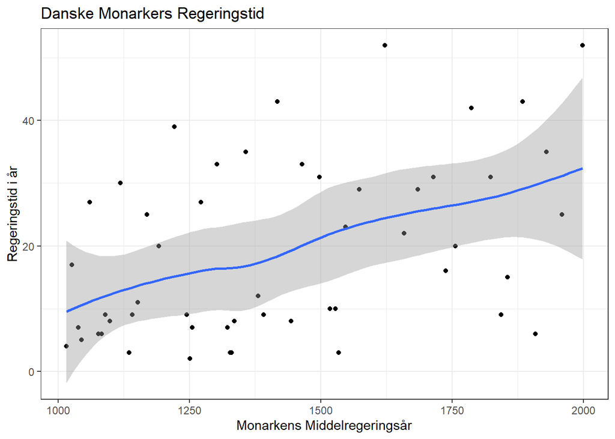

```r
# First I create a new tibble with a column of the mid years of reign

kings_midyear <- mutate(new_kings,
                        mid_year = (`regent slutår`+`Regent startår`)/2,.after=`Regent startår`)

# Then I plot the 'mid_year' and 'regeringstid' variables as x and y values with the "geom_point" function.
# I also use the "geom_smooth" function to plot a line of tendency in the plot.
# We see that the tendency is that the duration of monarchs reign have increased over time

kings_midyear %>%
  ggplot(,mapping=aes(x = `mid_year`,y = regeringstid))+
  geom_point()+
  geom_smooth()+
  theme_bw()+
  labs(title="Danske Monarkers Regeringstid",x="Monarkens Middelregeringsår",y="Regeringstid i år")
```

The tendency is that the duration of monarchs reign has increased over time. It appears that violent years of the early middle ages meant that monarchs died earlier and ruled for shorter timespans.